# Identifying Biases Within the 'Mental Health in Tech' survey

This report explores a dataset created to analyze the "frequency of mental health disorders among tech workers". The dataset, was created to raise awareness and imrpoving conditions for people with mental health disorders in the IT workplace. This dataset was chosen at random from kaggle.com to identify unfair/discriminatory biases within a dataset.

**Dataset Sourced**

- **Dataset used:** https://www.kaggle.com/datasets/osmi/mental-health-in-tech-survey/data — 2014 survey
- **Referenced by Dataset:** https://www.kaggle.com/datasets/osmi/mental-health-in-tech-2016 — referenced by dataset as ongoing 2016 survey

# Key Features

The Mental Health in the "Tech Survey" dataset contains the following:

| Feature | Survey Question |
| --- | --- |
| `Timestamp` |  |
| `Age` |  |
| `Gender` |  |
| `Country` |  |
| `state` | If you live in the United States, which state or territory do you live in? |
| `self_employed` | Are you self-employed? |
| `family_history` | Do you have a family history of mental illness? |
| `treatment` | Have you sought treatment for a mental health condition? |
| `work_interfere` | If you have a mental health condition, do you feel that it interferes with your work? |
| `no_employees` | How many employees does your company or organization have? |
| `remote_work` | Do you work remotely (outside of an office) at least 50% of the time? |
| `tech_company` | Is your employer primarily a tech company/organization? |
| `benefits` | Does your employer provide mental health benefits? |
| `care_options` | Do you know the options for mental health care your employer provides? |
| `wellness_program` | Has your employer ever discussed mental health as part of an employee wellness program? |
| `seek_help` | Does your employer provide resources to learn more about mental health issues and how to seek help? |
| `anonymity` | Is your anonymity protected if you choose to take advantage of mental health or substance abuse resources? |
| `leave` | How easy is it for you to take medical leave for a mental health condition? |
| `mental_health_consequence` | Do you think that discussing a mental health issue with your employer would have negative consequences? |
| `phys_health_consequence` | Do you think that discussing a physical health issue with your employer would have negative consequences? |
| `coworkers` | Would you be willing to discuss a mental health issue with your coworkers? |
| `supervisor` | Would you be willing to discuss a mental health issue with your direct supervisor(s)? |
| `mental_health_interview` | Would you bring up a mental health issue with a potential employer in an interview? |
| `phys_health_interview` | Would you bring up a physical health issue with a potential employer in an interview? |
| `mental_vs_physical` | Do you feel that your employer takes mental health as seriously as physical health? |
| `obs_consequence` | Have you heard of or observed negative consequences for coworkers with mental health conditions? |
| `comments` | Additional notes or comments |

# 1. Hypothesis and Ethical Relevance of Bias

Several features in the dataset may reveal inherent social, workplace, or cultural biases influencing the treatment of mental health in the workplace. Demographic factors like age, gender, and place of origin which could lead to discrimination, and unfair practices.

Also self-reported interferences of mental health in the workplace may be shaped by the individual's environment. Perceived consequnces of discplosure and anonymity protections offer insight into the general attitude towards mental health, this analysis will determine whether these features reflect patterns of unequal treatment or access, revealing systemic biases that may be embedded in the workplace mental health culture.

Using data like this in a predictive AI system without accounting for the sensitive attributes, could lead to models reinforcing discrimination, such as associating lower disclosure or treatment-seeking rates with certain age groups or genders. This could potentially risk introducing harmful stereotypes and unjust outcomes, especially in a workplace setting where AI-driven HR tools might be applied. The goal is to assess these risks and identify patterns of potential bias to avoid including into future training data.

# 2. EDA

This Exploratory Data Analysis will explore several features that would expect to reveal any biases within the Mental Health in tech Survey of 2014 and determine what could unintentionally enforce a biased and discriminatory AI system.

**Technologies and Tools Used**

- **Libraries**: `pandas`, `matplotlib`, `seaborn`, `numpy`, `statsmodels`
- **Statistical Summaries**: Variance, standard deviation, min, max, and distributions
- **Visualization**: Bar charts, histograms, and distribution plots to reveal patterns

```python
# Import libraries
import pandas as pd
import numpy as np
import matplotlib.pyplot as plt
import seaborn as sns
# import statsmodels.api as sm
# import statsmodels.formula.api as smf
# from scipy.stats import chi2_contingency

# Load dataset and check if valid
df = pd.read_csv('./data/survey.csv')
df.head()
```

|  | Timestamp | Age | Gender | Country | state | self_employed | family_history | treatment | work_interfere | no_employees | ... | leave | mental_health_consequence | phys_health_consequence | coworkers | supervisor | mental_health_interview | phys_health_interview | mental_vs_physical | obs_consequence | comments |
| --- | --- | --- | --- | --- | --- | --- | --- | --- | --- | --- | --- | --- | --- | --- | --- | --- | --- | --- | --- | --- | --- |
| 0 | 2014-08-27 11:29:31 | 37 | Female | United States | IL | NaN | No | Yes | Often | 6-25 | ... | Somewhat easy | No | No | Some of them | Yes | No | Maybe | Yes | No | NaN |
| 1 | 2014-08-27 11:29:37 | 44 | M | United States | IN | NaN | No | No | Rarely | More than 1000 | ... | Don't know | Maybe | No | No | No | No | No | Don't know | No | NaN |
| 2 | 2014-08-27 11:29:44 | 32 | Male | Canada | NaN | NaN | No | No | Rarely | 6-25 | ... | Somewhat difficult | No | No | Yes | Yes | Yes | Yes | No | No | NaN |
| 3 | 2014-08-27 11:29:46 | 31 | Male | United Kingdom | NaN | NaN | Yes | Yes | Often | 26-100 | ... | Somewhat difficult | Yes | Yes | Some of them | No | Maybe | Maybe | No | Yes | NaN |
| 4 | 2014-08-27 11:30:22 | 31 | Male | United States | TX | NaN | No | No | Never | 100-500 | ... | Don't know | No | No | Some of them | Yes | Yes | Yes | Don't know | No | NaN |

5 rows × 27 columns

```python
# Showing basic statistics and missing values
df.info()
df.describe(include='all')
df.isna().sum().sort_values(ascending=False)
```

```
<class 'pandas.core.frame.DataFrame'>
RangeIndex: 1259 entries, 0 to 1258
Data columns (total 27 columns):
 #   Column                     Non-Null Count  Dtype
---  ------                     --------------  -----
 0   Timestamp                  1259 non-null   object
 1   Age                        1259 non-null   int64
 2   Gender                     1259 non-null   object
 3   Country                    1259 non-null   object
 4   state                      744 non-null    object
 5   self_employed              1241 non-null   object
 6   family_history             1259 non-null   object
 7   treatment                  1259 non-null   object
 8   work_interfere             995 non-null    object
 9   no_employees               1259 non-null   object
```

[output cut: 19 more lines]

```
comments                     1095
state                         515
work_interfere                264
self_employed                  18
Gender                          0
Timestamp                       0
Age                             0
family_history                  0
treatment                       0
no_employees                    0
Country                         0
remote_work                     0
tech_company                    0
care_options                    0
benefits                        0
seek_help                       0
anonymity                       0
leave                           0
wellness_program                0
mental_health_consequence       0
phys_health_consequence         0
supervisor                      0
coworkers                       0
mental_health_interview         0
phys_health_interview           0
mental_vs_physical              0
obs_consequence                 0
dtype: int64
```

## 2.1 Statistical Analysis of Dataset Features

This analysis will either prove or disprove any disparities within the dataset that may cause an unfavorable bias towards model training

### 2.1.1 Gender distribution

For this dataset the gender values are too many and for clarity are normalized into three traditional categories `Male`, `Female`, `Nonbinary/Other`

```python
def normalize_gender(g):
    g = str(g).strip().lower()
    if g in ['male', 'm', 'cis male', 'man']:
        return 'Male'
    elif g in ['female', 'f', 'cis female', 'woman', 'female (cis)']:
        return 'Female'
    else:
        return 'Nonbinary/Other'

df['normalized_gender'] = df['Gender'].apply(normalize_gender)
```

```python
# Prepare a clean subset
df_clean = df[['treatment', 'normalized_gender', 'work_interfere', 'Age', 'no_employees']].dropna()

# Convert categorical variables
df_clean['treatment'] = df_clean['treatment'].map({'Yes': 1, 'No': 0})
df_clean['normalized_gender'] = df_clean['normalized_gender'].astype('category')
df_clean['work_interfere'] = df_clean['work_interfere'].astype('category')
df_clean['no_employees'] = df_clean['no_employees'].astype('category')

# Logistic regression using statsmodels
logit_model = smf.logit("treatment ~ C(normalized_gender) + C(work_interfere) + Age + C(no_employees)", data=df_clean).fit()

logit_model.summary()
```

```
Optimization terminated successfully.
         Current function value: 0.489509
         Iterations 6
```

Logit Regression Results

| Dep. Variable: | treatment | No. Observations: | 995 |
| --- | --- | --- | --- |
| Model: | Logit | Df Residuals: | 983 |
| Method: | MLE | Df Model: | 11 |
| Date: | Sun, 08 Jun 2025 | Pseudo R-squ.: | 0.2533 |
| Time: | 12:15:39 | Log-Likelihood: | -487.06 |
| converged: | True | LL-Null: | -652.31 |
| Covariance Type: | nonrobust | LLR p-value: | 3.234e-64 |

|  | coef | std err | z | P>\|z\| | [0.025 | 0.975] |
| --- | --- | --- | --- | --- | --- | --- |
| Intercept | -1.3797 | 0.342 | -4.030 | 0.000 | -2.051 | -0.709 |
| C(normalized_gender)[T.Male] | -0.8580 | 0.221 | -3.891 | 0.000 | -1.290 | -0.426 |
| C(normalized_gender)[T.Nonbinary/Other] | -0.3873 | 0.516 | -0.750 | 0.453 | -1.399 | 0.625 |
| C(work_interfere)[T.Often] | 3.6676 | 0.318 | 11.548 | 0.000 | 3.045 | 4.290 |
| C(work_interfere)[T.Rarely] | 2.6874 | 0.265 | 10.126 | 0.000 | 2.167 | 3.208 |
| C(work_interfere)[T.Sometimes] | 3.0443 | 0.233 | 13.077 | 0.000 | 2.588 | 3.501 |
| C(no_employees)[T.100-500] | 0.4930 | 0.303 | 1.628 | 0.104 | -0.101 | 1.087 |
| C(no_employees)[T.26-100] | 0.3350 | 0.267 | 1.253 | 0.210 | -0.189 | 0.859 |
| C(no_employees)[T.500-1000] | 0.6251 | 0.458 | 1.365 | 0.172 | -0.273 | 1.523 |
| C(no_employees)[T.6-25] | -0.1167 | 0.259 | -0.450 | 0.653 | -0.625 | 0.392 |
| C(no_employees)[T.More than 1000] | 0.3948 | 0.268 | 1.473 | 0.141 | -0.130 | 0.920 |
| Age | 5.301e-11 | 3.67e-10 | 0.145 | 0.885 | -6.66e-10 | 7.72e-10 |

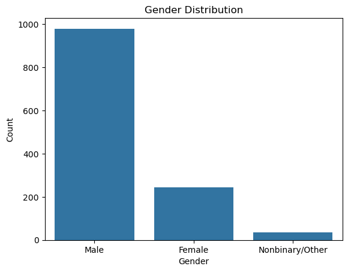

```python
# Gender distribution plot
sns.countplot(x='normalized_gender', data=df, order=df['normalized_gender'].value_counts().index)
plt.title("Gender Distribution")
plt.xlabel("Gender")
plt.ylabel("Count")
plt.show()
```

**Gender disparity:** There is obvious disproportionate amounts of the survey takers that identify as Male which shows a significant underrepresentation of Female and other genders. This implies that any model or inference drawn from the data could be skewed unless the imbalance is acknowledged and corrected. This may also reflect sampling bias in the tech industry of 2014.

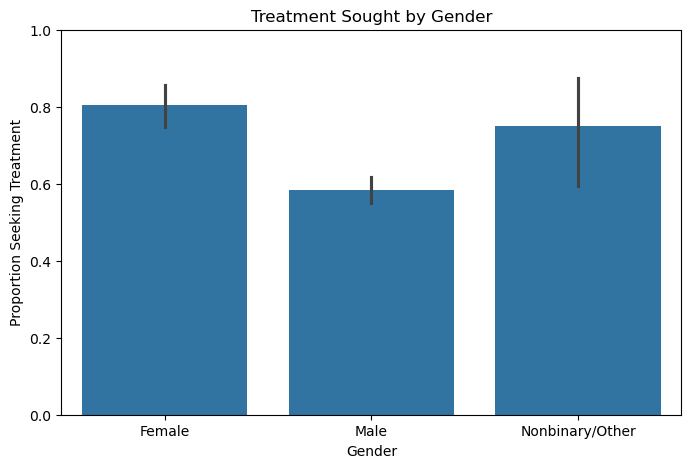

```python
# Treatment by gender
plt.figure(figsize=(8, 5))
sns.barplot(x='normalized_gender', y='treatment', data=df_clean, estimator=lambda x: sum(x)/len(x))
plt.title("Treatment Sought by Gender")
plt.ylabel("Proportion Seeking Treatment")
plt.xlabel("Gender")
plt.ylim(0, 1)
plt.show()
```

**Disproportionate trends:** This proportion graph shows that although the dataset is overwhelmingly male, they are less likely to seek treatment as compared to females and othe genders. This can outweigh the training data making males behavior greatly affect the overall trends seen elsewhere.

### 2.1.2 Treatment vs Work Interference

This is an analysis to identify bias for individuals who will seek help

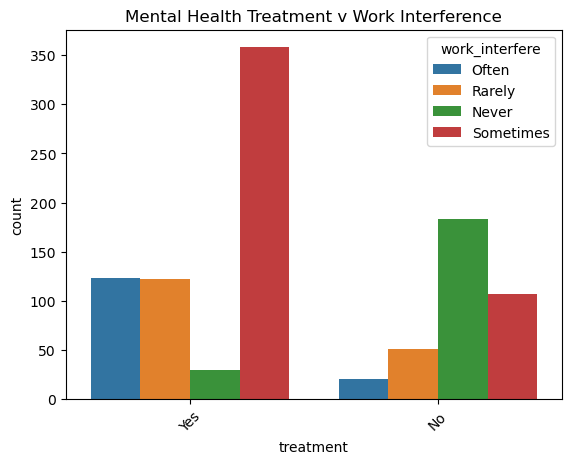

```python
# Treament v Work interefernce plot
sns.countplot(x='treatment', hue='work_interfere', data=df)
plt.title("Mental Health Treatment v Work Interference")
plt.xticks(rotation=45)
plt.show()
```

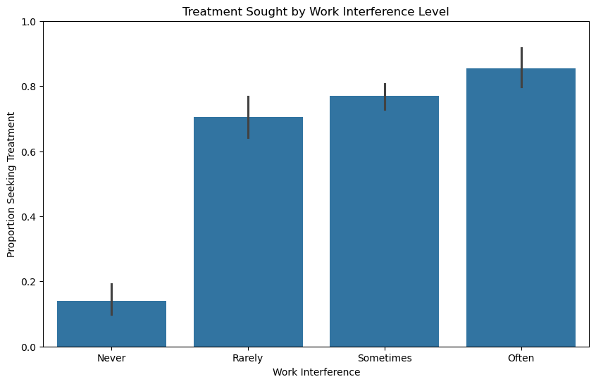

```python
# Visualize treatment by work interference
plt.figure(figsize=(10, 6))
sns.barplot(x='work_interfere', y='treatment', data=df_clean, order=['Never', 'Rarely', 'Sometimes', 'Often'], estimator=lambda x: sum(x)/len(x))
plt.title("Treatment Sought by Work Interference Level")
plt.ylabel("Proportion Seeking Treatment")
plt.xlabel("Work Interference")
plt.ylim(0, 1)
plt.show()
```

### 2.1.3 Age

This feature may cause discrimination by age, treating younger and older employees differently in regards to mental health.

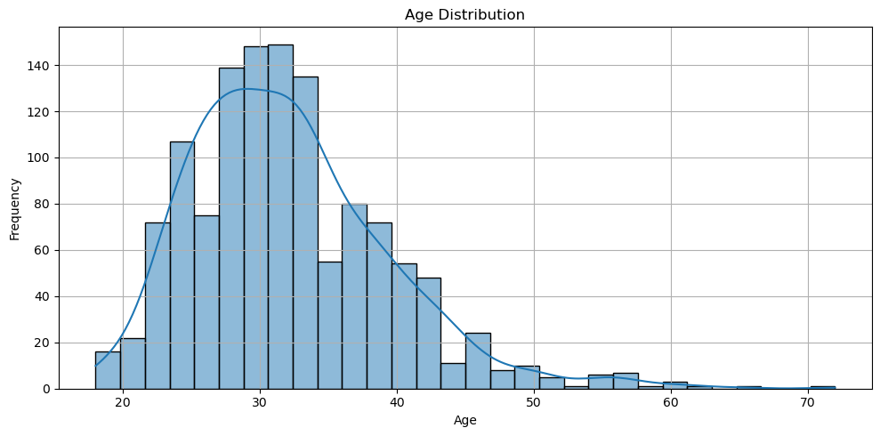

```
count    1251.000000
mean       32.076739
std         7.288272
min        18.000000
25%        27.000000
50%        31.000000
75%        36.000000
max        72.000000
Name: Age, dtype: float64
```

```python
# Clean age feature
df_clean = df[df['Age'].between(18, 100)]  # remove outliers or incorrect values

# Summary statistics
age_summary = df_clean['Age'].describe()

# Age distribution plot
plt.figure(figsize=(10, 5))
sns.histplot(df_clean['Age'], kde=True, bins=30)
plt.title("Age Distribution")
plt.xlabel("Age")
plt.ylabel("Frequency")
plt.grid(True)
plt.tight_layout()
plt.show()

age_summary
```

Here we can see that the majority of survey takers are around their 30s late 20s

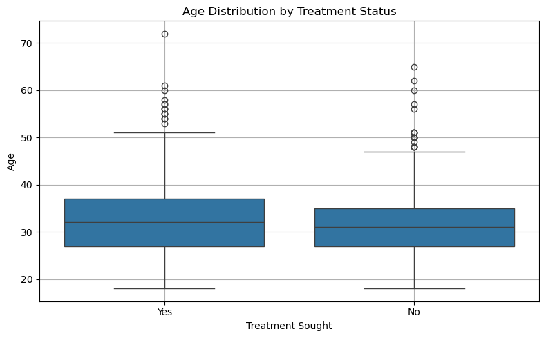

```python
# Age vs Treatment
plt.figure(figsize=(8, 5))
sns.boxplot(x='treatment', y='Age', data=df_clean)
plt.title("Age Distribution by Treatment Status")
plt.xlabel("Treatment Sought")
plt.ylabel("Age")
plt.grid(True)
plt.tight_layout()
plt.show()
```

This shows that there is more representation of younger survey takers

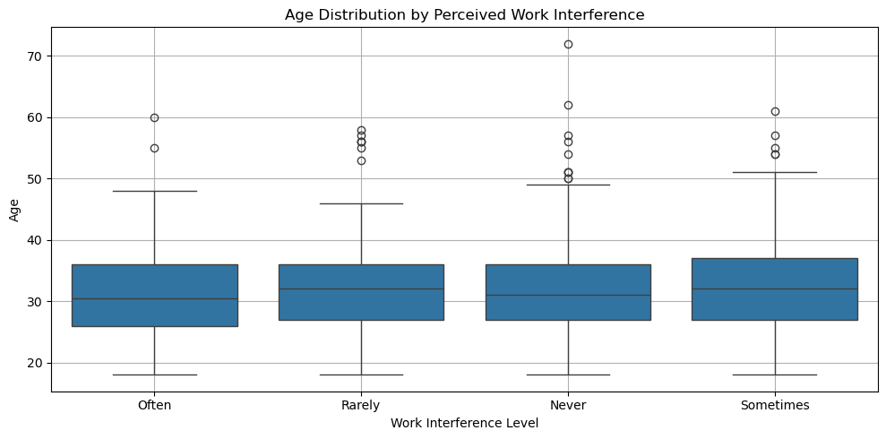

```python
# Age vs Work Interference
plt.figure(figsize=(10, 5))
sns.boxplot(x='work_interfere', y='Age', data=df_clean)
plt.title("Age Distribution by Perceived Work Interference")
plt.xlabel("Work Interference Level")
plt.ylabel("Age")
plt.grid(True)
plt.tight_layout()
plt.show()
```

Individuals reporting difficulty work due to mental health spans well but may over generalize

**Conclusion of Age findings:**

1. Disproprtioante Representation:
   - This dataset shows a high concentration towards people in their late 20s to mid 30s, which means older and younger individuals underrepresented, which can skew predictions or inferences.
2. Correlation of Mental Health Variables:
   - If age correlates towards treatment-seeking behaviors, work interference, or employer support, might teach a model to reflect societal or institutional age disparities.
3. Risk of Overgeneralization:
   - A model trained using this data may assume:
     - Younger workers seek treatment more
     - Older workers do not experience interference of work, due to mental health concerns, simply due to underrepresentation.

**In conclusion:** Using this data, even if a model is accurate statistically, it may fail certain age groups due to sampling bias, which can lead age discrimination in areas such as employee wellness, hiring, or benefits predictions.

### 2.1.4 Mental Health Consequence

This survey contains a feature related to the fear of disclosing mental health concerns to employers highlighting institutional stigma, leading to self-censorship or neglect of treatment.

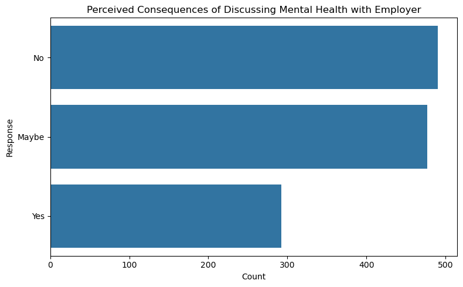

```python
# Clean target feature 'mental_health_consequence'
df_clean = df.dropna(subset=['mental_health_consequence'])

# Plot distribution of responses to mental_health_consequence
plt.figure(figsize=(8, 5))
sns.countplot(y='mental_health_consequence', data=df_clean, order=df_clean['mental_health_consequence'].value_counts().index)
plt.title("Perceived Consequences of Discussing Mental Health with Employer")
plt.xlabel("Count")
plt.ylabel("Response")
plt.tight_layout()
plt.show()
```

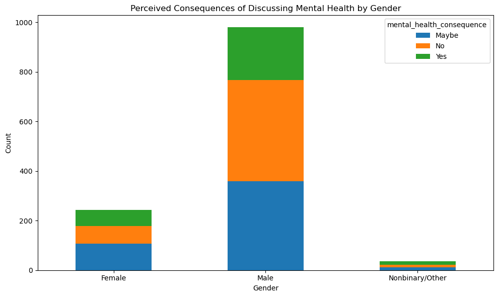

```python
# Analyze by gender
df_gender_filtered = df_clean.dropna(subset=['Gender'])

#  Use normalized gender
df_gender_filtered['normalized_gender'] = df_gender_filtered['Gender'].apply(normalize_gender)

# Plot stacked bar of mental_health_consequence by gender
contingency = pd.crosstab(df_gender_filtered['normalized_gender'], df_gender_filtered['mental_health_consequence'])
contingency.plot(kind='bar', stacked=True, figsize=(10, 6))
plt.title("Perceived Consequences of Discussing Mental Health by Gender")
plt.xlabel("Gender")
plt.ylabel("Count")
plt.xticks(rotation=0)
plt.tight_layout()
plt.show()
```

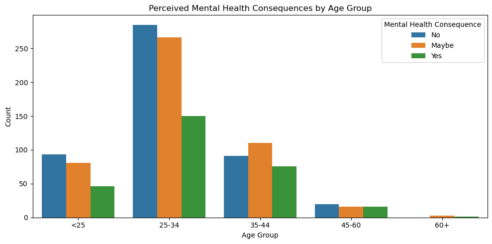

```python
# Age bins
bins = [0, 25, 35, 45, 60, 100]
labels = ['<25', '25-34', '35-44', '45-60', '60+']
df_clean['age_group'] = pd.cut(df_clean['Age'], bins=bins, labels=labels)

# Plot
plt.figure(figsize=(10, 5))
sns.countplot(data=df_clean, x='age_group', hue='mental_health_consequence')
plt.title("Perceived Mental Health Consequences by Age Group")
plt.xlabel("Age Group")
plt.ylabel("Count")
plt.legend(title="Mental Health Consequence")
plt.tight_layout()
plt.show()
```

**In Conclusion:**

**Implications:**

Such patterns suggest that the `mental_helath_consequence` feature should be treated with caution or excluded from models depending on the fairness and non-discriminatory goals of the system.

### 2.1.5 Country

This dataset includes countries which may highlight cultural and healthcare disparities

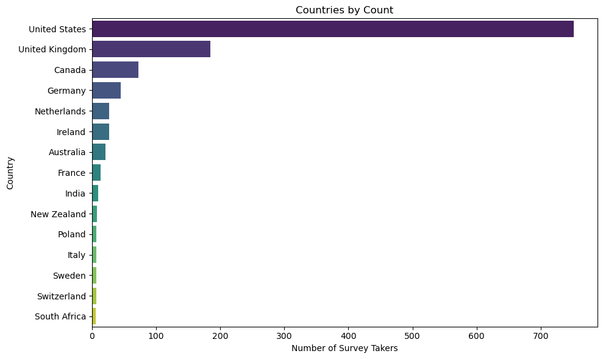

```python
# Clean country names (optional trimming or standardization could go here if needed)
df_clean = df['Country'].value_counts().head(15)

# Plot top 15 countries by respondent count
plt.figure(figsize=(10, 6))
sns.barplot(y=df_clean.index, x=df_clean.values, palette="viridis")
plt.title("Countries by Count")
plt.xlabel("Number of Survey Takers")
plt.ylabel("Country")
plt.tight_layout()
plt.show()
```

Here we can see that the US is the core focus of the dataset which can cause misrepresentation, potentially introducing geographic disparity. This could lead to US favored model assumptions, using US cultural workplace norms and attitudes towards mental health, while underrepresenting global perspectives.

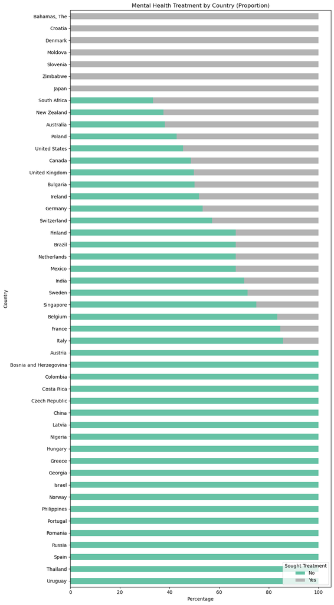

```python
# Clean 'Country' column by stripping whitespace
# df['Country'] = df['Country'].str.strip()

# Count the treatment responses by country
treatment_by_country = df.groupby(['Country', 'treatment']).size().unstack(fill_value=0)

# Normalize by row totals to get percentage breakdowns
treatment_pct = treatment_by_country.div(treatment_by_country.sum(axis=1), axis=0) * 100

# Plot as a stacked bar chart
treatment_pct_sorted = treatment_pct.sort_values(by='Yes', ascending=False)

plt.figure(figsize=(12, 10))
treatment_pct_sorted.plot(kind='barh', stacked=True, colormap='Set2', figsize=(10, 18))
plt.title("Mental Health Treatment by Country (Proportion)")
plt.xlabel("Percentage")
plt.ylabel("Country")
plt.legend(title="Sought Treatment", loc='lower right')
plt.tight_layout()
plt.gca().invert_yaxis()
plt.show()
```

**In conclusion:**

This analysis reveals notable disparities in mental health rates across different countries, while some variation is expected due to differences in healthcare systems, cultural norms, and awareness, the magnitude of variation suggests potential biases that could impact model fairness:

With these disparities it can be implied that a model trained wothout properly accounting for the disparity amongst the `Country` feature may unintentionally favor or disfavor individuals from certain regions, leading to geaographical or cultural discrimination.

# 3. Final Summary and Ethical Considerations

This analysis investigated the 'Mental Health in Tech Survey' from kaggle.com - https://www.kaggle.com/datasets/osmi/mental-health-in-tech-survey/data, finding several potentially unfair biased features of this 2014 Survey. The findings reveal that features such as **gender**, **age**, **mental health consequences**, and **country** exhibit patterns of disparity that may reinforce harmful or discriminatory outcomes if used in AI models without mitigation.

## 3.1 Identified Biases

- **Gender and Age**: These features showed a clear imbalance in attitudes and experiences toward treatment and workplace disclosure.
- **Mental Health Consequence**: This feature highlighted responses influenced by both gender and age, suggesting systemic stigma.
- **Country**: Disparities highlight geographic and cultural variation in treatment-seeking and perceptions of mental health support, with US-centric overrepresentation potentially skewing model fariness.

## 3.3 Conclusion

**In Conclusion**: This dataset has a very noble and positive goal providing a valuable reflection of mental health awareness but it must be approached with caution towards fairness and ethical concerns. By incorporating ethical guidelines when building an AI system it must be able to identify these among many other possible combinations of features to ensure that the model does not incidentally harbor any harmful assumptions or reinforce any unethical production of unfairness. Responsible feature selection and understanding is essential to avoid these potential negative impacts, if this were to be used in any machine learning applications.